```python
import matplotlib.pyplot as plt
```

# Plot a line graph for the following values x = [1, 2, 3] and y = [2, 4, 1] and print the respective x, y labels and title named as “line graph”.

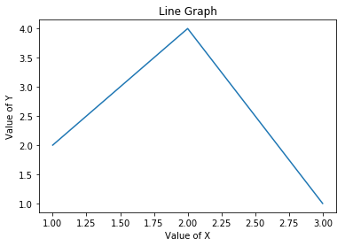

```python
x = [1,2,3]
y = [2,4,1]

plt.plot(x,y)
plt.xlabel("Value of X")
plt.ylabel("Value of Y")
plt.title("Line Graph")
plt.show()
```

# Create a multi-line graph for the following values x1 = [1, 2, 3 ] and y1 = [2, 4, 1] and plot the graph and mark label as “line 1 “ with green color and another set of values x2 = [1, 2, 3] and y2 = [4, 1, 3] and plot the graph and mark label as “line 2” with red color and print the respective x, y labels and title named as “two lines on the graph” use grid in the graph and grid color is black.

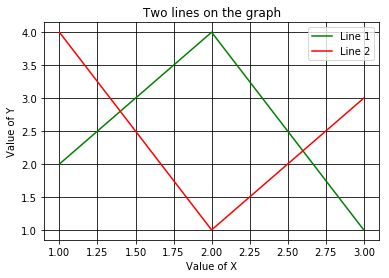

```python
x1 = [1, 2, 3]
y1 = [2, 4, 1]
x2 = [1, 2, 3]
y2 = [4, 1, 3]

plt.plot(x1, y1, 'g', label='Line 1')
plt.plot(x2, y2, 'r', label='Line 2')
plt.grid(color='k')
plt.xlabel("Value of X")
plt.ylabel("Value of Y")
plt.legend()
plt.title("Two lines on the graph")
plt.show()
```

# Create a bar graph for the movies data number of movies released in the year as x = [2016, 2017, 2018] and year as y = [1252, 1632, 1692] with colors red and blue and print the respective x, y labels and title named as “movies bar graph”.

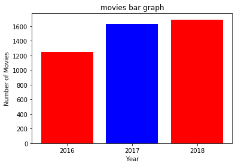

```python
x = [2016, 2017, 2018]
y = [1252, 1632, 1692]
color = ['r', 'b']
plt.bar(x,y, width=0.8, tick_label=x, color=color)
plt.xlabel("Year")
plt.ylabel("Number of Movies")
plt.title("movies bar graph")
plt.show()
```

# Plot a Pie graph with following values days = [1, 2, 3, 4, 5] and bike names as activities for example Enfield = [50, 40, 70, 80, 20] Honda = [80,20,20,50,60] Yahama = [70,20,60,40,60] KTM = [80,20,20,50,60] and with colors as [‘r’, ‘y’, ‘g’,’b’] and legend as “list of bikes details” and title as “pie plot”.

[output not shown]

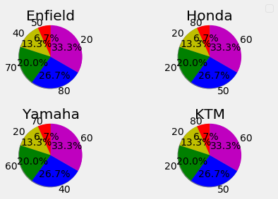

```python
days = [1,2,3,4,5]
enfield = [50,40,70,80,20]
honda = [80,20,20,50,60]
yamaha = [70,20,60,40,60]
ktm = [80,20,20,50,60]
activities = [enfield, honda, yamaha, ktm]
bike = ['Enfield', 'Honda', 'Yamaha', 'KTM']
colors = ['r', 'y', 'g', 'b', 'm']
explode = (0,0,0,0,0)
legends = 'list of bike details'
title = 'pie plot'

plt.style.use('fivethirtyeight')
#create a figure
fig=plt.figure()
#fig.title("Pie Plot")
fig.legend("list of bike details")
#define subplots and their positions in figure
plt1=fig.add_subplot(221)
plt2=fig.add_subplot(222)
plt3=fig.add_subplot(223)
plt4=fig.add_subplot(224)
#plotting points on each subplot
plt1.pie(days,labels=activities[0],colors=colors,startangle=90,shadow=True,explode=explode,radius=1.2,autopct='%1.1f%%')
plt1.set_title(bike[0])

plt2.pie(days,labels=activities[1],colors=colors,startangle=90,shadow=True,explode=explode,radius=1.2,autopct='%1.1f%%')
plt2.set_title(bike[1])

plt3.pie(days,labels=activities[2],colors=colors,startangle=90,shadow=True,explode=explode,radius=1.2,autopct='%1.1f%%')
plt3.set_title(bike[2])

plt4.pie(days,labels=activities[3],colors=colors,startangle=90,shadow=True,explode=explode,radius=1.2,autopct='%1.1f%%')
plt4.set_title(bike[3])
fig.subplots_adjust(hspace=.5,wspace=0.5)

plt.show()
```

# Use the same tabular data and create a scatter plot days as x values [1,2,3,4,5] and bike details as y1,y2,y3,y4,y5 namely label as ‘Enfield’,’Honda’,’Yahama’ and ‘KTM’ and x, y labels as ‘days’ and ‘distance’.

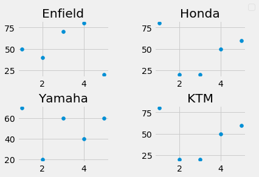

```python
plt.style.use('fivethirtyeight')
fig=plt.figure()
fig.legend("list of bike details")
plt1=fig.add_subplot(221)
plt2=fig.add_subplot(222)
plt3=fig.add_subplot(223)
plt4=fig.add_subplot(224)


plt1.scatter(days, activities[0])
plt1.set_title(bike[0])

plt2.scatter(days, activities[1])
plt2.set_title(bike[1])

plt3.scatter(days, activities[2])
plt3.set_title(bike[2])

plt4.scatter(days, activities[3])
plt4.set_title(bike[3])
fig.subplots_adjust(hspace=0.5, wspace=0.5)

plt.show()
```

# Plot a histogram

days =[50 ,80,70,80,40,20,20,20,70,20,60,20,80,50,40,50,20,60,60,60] bins = [0,10,20,40,50,60,70,80,90,100] Print the x, y labels as “distance” and “km count”

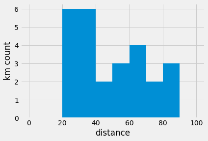

```python
days =[50 ,80,70,80,40,20,20,20,70,20,60,20,80,50,40,50,20,60,60,60]
bins = [0,10,20,40,50,60,70,80,90,100]

plt.xlabel('distance')
plt.ylabel('km count')
plt.hist(days, bins)
plt.show()
```